# Risk Factor Analysis

## Outcome Variable

**Outcome Variable:** pers_wasted624

## Predictor Variables

**Intervention Variable:** pers_wasted06

**Adjustment Set:**

unadjusted

## Stratifying Variables

The analysis was stratified on these variable(s):

- studyid
- country

## Data Summary

| studyid | country | pers_wasted06 | pers_wasted624 | n_cell | n |
| --- | --- | --- | --- | --- | --- |
| CMC-V-BCS-2002 | INDIA | 0 | 0 | 307 | 370 |
| CMC-V-BCS-2002 | INDIA | 0 | 1 | 11 | 370 |
| CMC-V-BCS-2002 | INDIA | 1 | 0 | 35 | 370 |
| CMC-V-BCS-2002 | INDIA | 1 | 1 | 17 | 370 |
| CMIN | BANGLADESH | 0 | 0 | 223 | 252 |
| CMIN | BANGLADESH | 0 | 1 | 19 | 252 |
| CMIN | BANGLADESH | 1 | 0 | 4 | 252 |
| CMIN | BANGLADESH | 1 | 1 | 6 | 252 |
| COHORTS | GUATEMALA | 0 | 0 | 934 | 1017 |
| COHORTS | GUATEMALA | 0 | 1 | 31 | 1017 |
| COHORTS | GUATEMALA | 1 | 0 | 42 | 1017 |
| COHORTS | GUATEMALA | 1 | 1 | 10 | 1017 |
| COHORTS | INDIA | 0 | 0 | 5684 | 6892 |
| COHORTS | INDIA | 0 | 1 | 277 | 6892 |
| COHORTS | INDIA | 1 | 0 | 438 | 6892 |
| COHORTS | INDIA | 1 | 1 | 493 | 6892 |
| COHORTS | PHILIPPINES | 0 | 0 | 2467 | 2808 |
| COHORTS | PHILIPPINES | 0 | 1 | 161 | 2808 |
| COHORTS | PHILIPPINES | 1 | 0 | 115 | 2808 |
| COHORTS | PHILIPPINES | 1 | 1 | 65 | 2808 |
| CONTENT | PERU | 0 | 0 | 215 | 215 |
| CONTENT | PERU | 0 | 1 | 0 | 215 |
| CONTENT | PERU | 1 | 0 | 0 | 215 |
| CONTENT | PERU | 1 | 1 | 0 | 215 |
| EE | PAKISTAN | 0 | 0 | 313 | 374 |
| EE | PAKISTAN | 0 | 1 | 35 | 374 |
| EE | PAKISTAN | 1 | 0 | 12 | 374 |
| EE | PAKISTAN | 1 | 1 | 14 | 374 |
| GMS-Nepal | NEPAL | 0 | 0 | 452 | 590 |
| GMS-Nepal | NEPAL | 0 | 1 | 70 | 590 |

[output cut: 90 more lines]

The following strata were considered:

- studyid: CMC-V-BCS-2002, country: INDIA
- studyid: CMIN, country: BANGLADESH
- studyid: COHORTS, country: GUATEMALA
- studyid: COHORTS, country: INDIA
- studyid: COHORTS, country: PHILIPPINES
- studyid: CONTENT, country: PERU
- studyid: EE, country: PAKISTAN
- studyid: GMS-Nepal, country: NEPAL
- studyid: Guatemala BSC, country: GUATEMALA
- studyid: IRC, country: INDIA
- studyid: JiVitA-3, country: BANGLADESH
- studyid: JiVitA-4, country: BANGLADESH
- studyid: Keneba, country: GAMBIA
- studyid: LCNI-5, country: MALAWI
- studyid: MAL-ED, country: BANGLADESH
- studyid: MAL-ED, country: BRAZIL
- studyid: MAL-ED, country: INDIA
- studyid: MAL-ED, country: NEPAL
- studyid: MAL-ED, country: PERU
- studyid: MAL-ED, country: SOUTH AFRICA
- studyid: MAL-ED, country: TANZANIA, UNITED REPUBLIC OF
- studyid: NIH-Birth, country: BANGLADESH
- studyid: NIH-Crypto, country: BANGLADESH
- studyid: PROBIT, country: BELARUS
- studyid: PROVIDE, country: BANGLADESH
- studyid: ResPak, country: PAKISTAN
- studyid: SAS-CompFeed, country: INDIA
- studyid: SAS-FoodSuppl, country: INDIA
- studyid: TanzaniaChild2, country: TANZANIA, UNITED REPUBLIC OF
- studyid: ZVITAMBO, country: ZIMBABWE

### Dropped Strata

Some strata were dropped due to rare outcomes:

- studyid: CMIN, country: BANGLADESH
- studyid: CONTENT, country: PERU
- studyid: Guatemala BSC, country: GUATEMALA
- studyid: MAL-ED, country: BANGLADESH
- studyid: MAL-ED, country: BRAZIL
- studyid: MAL-ED, country: NEPAL
- studyid: MAL-ED, country: PERU
- studyid: MAL-ED, country: SOUTH AFRICA
- studyid: MAL-ED, country: TANZANIA, UNITED REPUBLIC OF

## Methods Detail

We’re interested in the causal parameters $E[Y_a]$ for all values of $a \in \mathcal{A}$. These parameters represent the mean outcome if, possibly contrary to fact, we intervened to set all units to have $A=a$. Under the randomization and positivity assumptions, these are identified by the statistical parameters $\psi_a=E_W[E_{Y|A,W}(Y|A=a,W)]$. In addition, we’re interested in the mean of $Y$, $E[Y]$ under no intervention (the observed mean). We will estimate these parameters by using SuperLearner to fit the relevant likelihood factors – $E_{Y|A,W}(Y|A=a,W)$ and $p(A=a|W)$, and then updating our likelihood fit using a joint TMLE.

For unadjusted analyses ($W=\{\}$), initial likelihoods were estimated using Lrnr_glm to estimate the simple $E(Y|A)$ and Lrnr_mean to estimate $p(A)$. For adjusted analyses, a small library containing Lrnr_glmnet, Lrnr_xgboost, and Lrnr_mean was used.

Having estimated these parameters, we will then use the delta method to estimate relative risks and attributable risks relative to a prespecified baseline level of $A$.

# Results Detail

## Results Plots

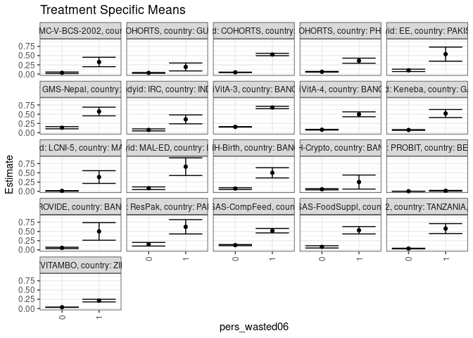

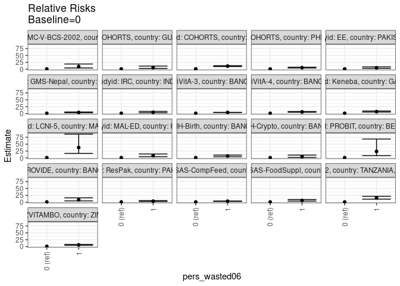

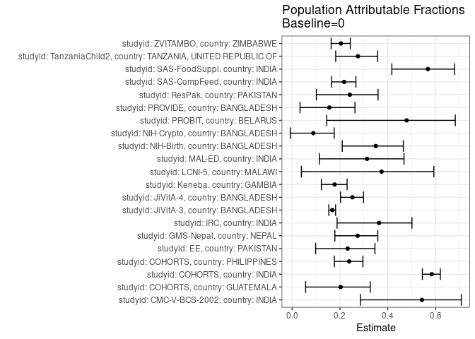

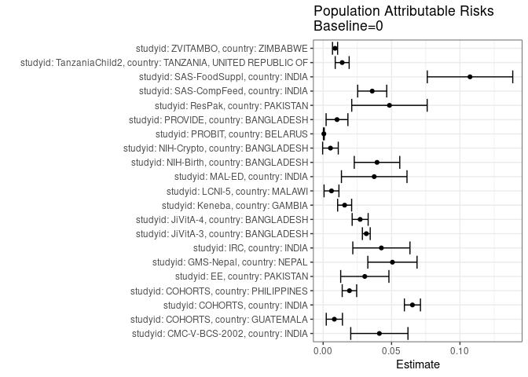

## Results Table

### Parameter: TSM

| studyid | country | intervention_level | baseline_level | estimate | ci_lower | ci_upper |
| --- | --- | --- | --- | --- | --- | --- |
| CMC-V-BCS-2002 | INDIA | 0 | NA | 0.0345912 | 0.0144789 | 0.0547034 |
| CMC-V-BCS-2002 | INDIA | 1 | NA | 0.3269231 | 0.1992530 | 0.4545932 |
| COHORTS | GUATEMALA | 0 | NA | 0.0321244 | 0.0209936 | 0.0432551 |
| COHORTS | GUATEMALA | 1 | NA | 0.1923077 | 0.0851357 | 0.2994797 |
| COHORTS | INDIA | 0 | NA | 0.0464687 | 0.0411247 | 0.0518127 |
| COHORTS | INDIA | 1 | NA | 0.5295381 | 0.4974743 | 0.5616020 |
| COHORTS | PHILIPPINES | 0 | NA | 0.0612633 | 0.0520930 | 0.0704336 |
| COHORTS | PHILIPPINES | 1 | NA | 0.3611111 | 0.2909297 | 0.4312926 |
| EE | PAKISTAN | 0 | NA | 0.1005747 | 0.0689325 | 0.1322169 |
| EE | PAKISTAN | 1 | NA | 0.5384615 | 0.3465840 | 0.7303391 |
| GMS-Nepal | NEPAL | 0 | NA | 0.1340996 | 0.1048427 | 0.1633566 |
| GMS-Nepal | NEPAL | 1 | NA | 0.5735294 | 0.4558815 | 0.6911774 |
| IRC | INDIA | 0 | NA | 0.0744986 | 0.0469164 | 0.1020807 |
| IRC | INDIA | 1 | NA | 0.3606557 | 0.2400058 | 0.4813057 |
| JiVitA-3 | BANGLADESH | 0 | NA | 0.1564638 | 0.1502954 | 0.1626323 |
| JiVitA-3 | BANGLADESH | 1 | NA | 0.6804620 | 0.6486724 | 0.7122516 |
| JiVitA-4 | BANGLADESH | 0 | NA | 0.0802205 | 0.0708850 | 0.0895559 |
| JiVitA-4 | BANGLADESH | 1 | NA | 0.4970588 | 0.4303387 | 0.5637789 |
| Keneba | GAMBIA | 0 | NA | 0.0726207 | 0.0618158 | 0.0834255 |
| Keneba | GAMBIA | 1 | NA | 0.5185185 | 0.4096827 | 0.6273544 |
| LCNI-5 | MALAWI | 0 | NA | 0.0102041 | 0.0031022 | 0.0173060 |
| LCNI-5 | MALAWI | 1 | NA | 0.3846154 | 0.2119598 | 0.5572710 |
| MAL-ED | INDIA | 0 | NA | 0.0818182 | 0.0455227 | 0.1181136 |
| MAL-ED | INDIA | 1 | NA | 0.6666667 | 0.4275982 | 0.9057351 |
| NIH-Birth | BANGLADESH | 0 | NA | 0.0731707 | 0.0501385 | 0.0962029 |
| NIH-Birth | BANGLADESH | 1 | NA | 0.5000000 | 0.3612816 | 0.6387184 |
| NIH-Crypto | BANGLADESH | 0 | NA | 0.0549296 | 0.0381589 | 0.0717003 |
| NIH-Crypto | BANGLADESH | 1 | NA | 0.2500000 | 0.0600972 | 0.4399028 |
| PROBIT | BELARUS | 0 | NA | 0.0005652 | 0.0000742 | 0.0010561 |
| PROBIT | BELARUS | 1 | NA | 0.0133929 | 0.0041540 | 0.0226317 |
| PROVIDE | BANGLADESH | 0 | NA | 0.0549085 | 0.0366394 | 0.0731775 |
| PROVIDE | BANGLADESH | 1 | NA | 0.5000000 | 0.2613176 | 0.7386824 |
| ResPak | PAKISTAN | 0 | NA | 0.1523810 | 0.1036692 | 0.2010927 |
| ResPak | PAKISTAN | 1 | NA | 0.6250000 | 0.4308989 | 0.8191011 |
| SAS-CompFeed | INDIA | 0 | NA | 0.1288783 | 0.1140339 | 0.1437227 |
| SAS-CompFeed | INDIA | 1 | NA | 0.5196850 | 0.4595908 | 0.5797792 |
| SAS-FoodSuppl | INDIA | 0 | NA | 0.0816993 | 0.0509717 | 0.1124270 |
| SAS-FoodSuppl | INDIA | 1 | NA | 0.5312500 | 0.4313022 | 0.6311978 |
| TanzaniaChild2 | TANZANIA, UNITED REPUBLIC OF | 0 | NA | 0.0366226 | 0.0283176 | 0.0449275 |
| TanzaniaChild2 | TANZANIA, UNITED REPUBLIC OF | 1 | NA | 0.5769231 | 0.4426086 | 0.7112375 |
| ZVITAMBO | ZIMBABWE | 0 | NA | 0.0338850 | 0.0303755 | 0.0373946 |
| ZVITAMBO | ZIMBABWE | 1 | NA | 0.2134615 | 0.1782418 | 0.2486813 |

### Parameter: E(Y)

| studyid | country | intervention_level | baseline_level | estimate | ci_lower | ci_upper |
| --- | --- | --- | --- | --- | --- | --- |
| CMC-V-BCS-2002 | INDIA | NA | NA | 0.0756757 | 0.0486905 | 0.1026609 |
| COHORTS | GUATEMALA | NA | NA | 0.0403147 | 0.0282199 | 0.0524094 |
| COHORTS | INDIA | NA | NA | 0.1117237 | 0.1042858 | 0.1191617 |
| COHORTS | PHILIPPINES | NA | NA | 0.0804843 | 0.0704205 | 0.0905481 |
| EE | PAKISTAN | NA | NA | 0.1310160 | 0.0967738 | 0.1652583 |
| GMS-Nepal | NEPAL | NA | NA | 0.1847458 | 0.1534039 | 0.2160876 |
| IRC | INDIA | NA | NA | 0.1170732 | 0.0859146 | 0.1482317 |
| JiVitA-3 | BANGLADESH | NA | NA | 0.1880070 | 0.1814627 | 0.1945512 |
| JiVitA-4 | BANGLADESH | NA | NA | 0.1072724 | 0.0967392 | 0.1178055 |
| Keneba | GAMBIA | NA | NA | 0.0883377 | 0.0767324 | 0.0999430 |
| LCNI-5 | MALAWI | NA | NA | 0.0163112 | 0.0075116 | 0.0251108 |
| MAL-ED | INDIA | NA | NA | 0.1191489 | 0.0776405 | 0.1606574 |
| NIH-Birth | BANGLADESH | NA | NA | 0.1125461 | 0.0859151 | 0.1391771 |
| NIH-Crypto | BANGLADESH | NA | NA | 0.0602740 | 0.0429977 | 0.0775502 |
| PROBIT | BELARUS | NA | NA | 0.0010846 | 0.0004977 | 0.0016715 |
| PROVIDE | BANGLADESH | NA | NA | 0.0650407 | 0.0455353 | 0.0845460 |
| ResPak | PAKISTAN | NA | NA | 0.2008547 | 0.1494120 | 0.2522974 |
| SAS-CompFeed | INDIA | NA | NA | 0.1647399 | 0.1451050 | 0.1843747 |
| SAS-FoodSuppl | INDIA | NA | NA | 0.1890547 | 0.1507312 | 0.2273783 |
| TanzaniaChild2 | TANZANIA, UNITED REPUBLIC OF | NA | NA | 0.0505451 | 0.0409848 | 0.0601054 |
| ZVITAMBO | ZIMBABWE | NA | NA | 0.0425869 | 0.0387663 | 0.0464075 |

### Parameter: RR

| studyid | country | intervention_level | baseline_level | estimate | ci_lower | ci_upper |
| --- | --- | --- | --- | --- | --- | --- |
| CMC-V-BCS-2002 | INDIA | 0 | 0 | 1.000000 | 1.000000 | 1.000000 |
| CMC-V-BCS-2002 | INDIA | 1 | 0 | 9.451049 | 4.691365 | 19.039732 |
| COHORTS | GUATEMALA | 0 | 0 | 1.000000 | 1.000000 | 1.000000 |
| COHORTS | GUATEMALA | 1 | 0 | 5.986352 | 3.105754 | 11.538717 |
| COHORTS | INDIA | 0 | 0 | 1.000000 | 1.000000 | 1.000000 |
| COHORTS | INDIA | 1 | 0 | 11.395584 | 10.006721 | 12.977212 |
| COHORTS | PHILIPPINES | 0 | 0 | 1.000000 | 1.000000 | 1.000000 |
| COHORTS | PHILIPPINES | 1 | 0 | 5.894410 | 4.612146 | 7.533168 |
| EE | PAKISTAN | 0 | 0 | 1.000000 | 1.000000 | 1.000000 |
| EE | PAKISTAN | 1 | 0 | 5.353846 | 3.328293 | 8.612123 |
| GMS-Nepal | NEPAL | 0 | 0 | 1.000000 | 1.000000 | 1.000000 |
| GMS-Nepal | NEPAL | 1 | 0 | 4.276891 | 3.170102 | 5.770096 |
| IRC | INDIA | 0 | 0 | 1.000000 | 1.000000 | 1.000000 |
| IRC | INDIA | 1 | 0 | 4.841110 | 2.939264 | 7.973541 |
| JiVitA-3 | BANGLADESH | 0 | 0 | 1.000000 | 1.000000 | 1.000000 |
| JiVitA-3 | BANGLADESH | 1 | 0 | 4.349005 | 4.100465 | 4.612609 |
| JiVitA-4 | BANGLADESH | 0 | 0 | 1.000000 | 1.000000 | 1.000000 |
| JiVitA-4 | BANGLADESH | 1 | 0 | 6.196161 | 5.193511 | 7.392380 |
| Keneba | GAMBIA | 0 | 0 | 1.000000 | 1.000000 | 1.000000 |
| Keneba | GAMBIA | 1 | 0 | 7.140097 | 5.520368 | 9.235070 |
| LCNI-5 | MALAWI | 0 | 0 | 1.000000 | 1.000000 | 1.000000 |
| LCNI-5 | MALAWI | 1 | 0 | 37.692308 | 16.465322 | 86.284983 |
| MAL-ED | INDIA | 0 | 0 | 1.000000 | 1.000000 | 1.000000 |
| MAL-ED | INDIA | 1 | 0 | 8.148148 | 4.606020 | 14.414249 |
| NIH-Birth | BANGLADESH | 0 | 0 | 1.000000 | 1.000000 | 1.000000 |
| NIH-Birth | BANGLADESH | 1 | 0 | 6.833333 | 4.491674 | 10.395777 |
| NIH-Crypto | BANGLADESH | 0 | 0 | 1.000000 | 1.000000 | 1.000000 |
| NIH-Crypto | BANGLADESH | 1 | 0 | 4.551282 | 2.007191 | 10.319981 |
| PROBIT | BELARUS | 0 | 0 | 1.000000 | 1.000000 | 1.000000 |
| PROBIT | BELARUS | 1 | 0 | 23.696429 | 8.189156 | 68.568818 |
| PROVIDE | BANGLADESH | 0 | 0 | 1.000000 | 1.000000 | 1.000000 |
| PROVIDE | BANGLADESH | 1 | 0 | 9.106061 | 5.088919 | 16.294295 |
| ResPak | PAKISTAN | 0 | 0 | 1.000000 | 1.000000 | 1.000000 |
| ResPak | PAKISTAN | 1 | 0 | 4.101562 | 2.626572 | 6.404857 |
| SAS-CompFeed | INDIA | 0 | 0 | 1.000000 | 1.000000 | 1.000000 |
| SAS-CompFeed | INDIA | 1 | 0 | 4.032371 | 3.444208 | 4.720973 |
| SAS-FoodSuppl | INDIA | 0 | 0 | 1.000000 | 1.000000 | 1.000000 |
| SAS-FoodSuppl | INDIA | 1 | 0 | 6.502500 | 4.270150 | 9.901879 |
| TanzaniaChild2 | TANZANIA, UNITED REPUBLIC OF | 0 | 0 | 1.000000 | 1.000000 | 1.000000 |
| TanzaniaChild2 | TANZANIA, UNITED REPUBLIC OF | 1 | 0 | 15.753205 | 11.382097 | 21.802966 |
| ZVITAMBO | ZIMBABWE | 0 | 0 | 1.000000 | 1.000000 | 1.000000 |
| ZVITAMBO | ZIMBABWE | 1 | 0 | 6.299583 | 5.184511 | 7.654482 |

### Parameter: PAR

| studyid | country | intervention_level | baseline_level | estimate | ci_lower | ci_upper |
| --- | --- | --- | --- | --- | --- | --- |
| CMC-V-BCS-2002 | INDIA | 0 | NA | 0.0410845 | 0.0201705 | 0.0619985 |
| COHORTS | GUATEMALA | 0 | NA | 0.0081903 | 0.0022693 | 0.0141113 |
| COHORTS | INDIA | 0 | NA | 0.0652550 | 0.0593830 | 0.0711270 |
| COHORTS | PHILIPPINES | 0 | NA | 0.0192210 | 0.0139327 | 0.0245094 |
| EE | PAKISTAN | 0 | NA | 0.0304413 | 0.0128201 | 0.0480626 |
| GMS-Nepal | NEPAL | 0 | NA | 0.0506461 | 0.0326559 | 0.0686364 |
| IRC | INDIA | 0 | NA | 0.0425746 | 0.0216830 | 0.0634662 |
| JiVitA-3 | BANGLADESH | 0 | NA | 0.0315431 | 0.0286849 | 0.0344013 |
| JiVitA-4 | BANGLADESH | 0 | NA | 0.0270519 | 0.0212072 | 0.0328966 |
| Keneba | GAMBIA | 0 | NA | 0.0157170 | 0.0106015 | 0.0208326 |
| LCNI-5 | MALAWI | 0 | NA | 0.0061071 | 0.0006741 | 0.0115401 |
| MAL-ED | INDIA | 0 | NA | 0.0373308 | 0.0133773 | 0.0612842 |
| NIH-Birth | BANGLADESH | 0 | NA | 0.0393754 | 0.0227440 | 0.0560068 |
| NIH-Crypto | BANGLADESH | 0 | NA | 0.0053444 | -0.0003673 | 0.0110561 |
| PROBIT | BELARUS | 0 | NA | 0.0005194 | 0.0002130 | 0.0008258 |
| PROVIDE | BANGLADESH | 0 | NA | 0.0101322 | 0.0021706 | 0.0180938 |
| ResPak | PAKISTAN | 0 | NA | 0.0484737 | 0.0209011 | 0.0760464 |
| SAS-CompFeed | INDIA | 0 | NA | 0.0358616 | 0.0252457 | 0.0464775 |
| SAS-FoodSuppl | INDIA | 0 | NA | 0.1073554 | 0.0761231 | 0.1385877 |
| TanzaniaChild2 | TANZANIA, UNITED REPUBLIC OF | 0 | NA | 0.0139225 | 0.0088253 | 0.0190198 |
| ZVITAMBO | ZIMBABWE | 0 | NA | 0.0087019 | 0.0068380 | 0.0105657 |

### Parameter: PAF

| studyid | country | intervention_level | baseline_level | estimate | ci_lower | ci_upper |
| --- | --- | --- | --- | --- | --- | --- |
| CMC-V-BCS-2002 | INDIA | 0 | NA | 0.5429021 | 0.2854446 | 0.7075965 |
| COHORTS | GUATEMALA | 0 | NA | 0.2031594 | 0.0565772 | 0.3269666 |
| COHORTS | INDIA | 0 | NA | 0.5840748 | 0.5447988 | 0.6199620 |
| COHORTS | PHILIPPINES | 0 | NA | 0.2388168 | 0.1768914 | 0.2960834 |
| EE | PAKISTAN | 0 | NA | 0.2323481 | 0.0983443 | 0.3464363 |
| GMS-Nepal | NEPAL | 0 | NA | 0.2741397 | 0.1787558 | 0.3584452 |
| IRC | INDIA | 0 | NA | 0.3636581 | 0.1880171 | 0.5013059 |
| JiVitA-3 | BANGLADESH | 0 | NA | 0.1677763 | 0.1533785 | 0.1819293 |
| JiVitA-4 | BANGLADESH | 0 | NA | 0.2521798 | 0.2025212 | 0.2987462 |
| Keneba | GAMBIA | 0 | NA | 0.1779198 | 0.1223229 | 0.2299949 |
| LCNI-5 | MALAWI | 0 | NA | 0.3744113 | 0.0387300 | 0.5928707 |
| MAL-ED | INDIA | 0 | NA | 0.3133117 | 0.1136573 | 0.4679927 |
| NIH-Birth | BANGLADESH | 0 | NA | 0.3498601 | 0.2096789 | 0.4651769 |
| NIH-Crypto | BANGLADESH | 0 | NA | 0.0886684 | -0.0078075 | 0.1759087 |
| PROBIT | BELARUS | 0 | NA | 0.4788998 | 0.1448179 | 0.6824706 |
| PROVIDE | BANGLADESH | 0 | NA | 0.1557820 | 0.0331417 | 0.2628662 |
| ResPak | PAKISTAN | 0 | NA | 0.2413374 | 0.1014563 | 0.3594424 |
| SAS-CompFeed | INDIA | 0 | NA | 0.2176862 | 0.1650298 | 0.2670219 |
| SAS-FoodSuppl | INDIA | 0 | NA | 0.5678535 | 0.4171645 | 0.6795826 |
| TanzaniaChild2 | TANZANIA, UNITED REPUBLIC OF | 0 | NA | 0.2754473 | 0.1823889 | 0.3579140 |
| ZVITAMBO | ZIMBABWE | 0 | NA | 0.2043321 | 0.1632674 | 0.2433815 |